# women’s ratings of attractiveness in males in conjunction with the colour red

*N* removed NAs: 2

*N* removed <18: 26

*N* total clean: 119

| Group | *N* | *M*<sub>age</sub> | *M*<sub>rating</sub> |
| --- | --- | --- | --- |
| Control | 64 | 21.05 | 5.88 |
| Experim | 55 | 21.58 | 7.05 |

**Main analysis results**

*t*(117) = -7.86, *p* < .001

# women’s ratings of attractiveness in males in conjunction with the colour red

Analysing Data, Spring 2020

# Methods

## Participants

The distribution of participant ages has been illustrated in a graph.

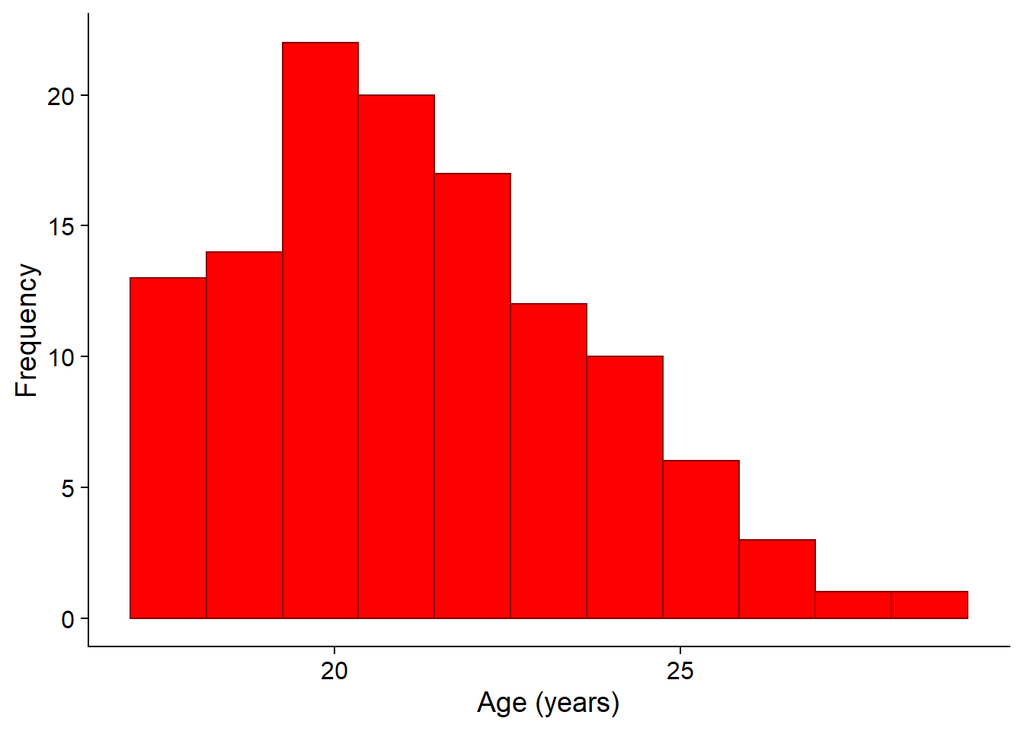

```r
age_plot
```

```r
age_desc %>%
    mutate(GROUP = str_to_sentence(GROUP)) %>%
  kable(col.names = c("Group", "n", "mean age", "sd", "min age", "max age" ),caption = "Table 1 *age descriptives table*", digits = 2) %>%
  kable_styling()
```

Table 1 *age descriptives table*

| Group | n | mean age | sd | min age | max age |
| --- | --- | --- | --- | --- | --- |
| Control | 64 | 21.05 | 2.24 | 18 | 29 |
| Experimental | 55 | 21.58 | 2.31 | 18 | 27 |

```r
age_desc
```

```
## # A tibble: 2 x 6
##   GROUP            n  mean    sd   min   max
##   <fct>        <int> <dbl> <dbl> <dbl> <dbl>
## 1 control         64  21.0  2.24    18    29
## 2 experimental    55  21.6  2.31    18    27
```

## Design

The research question was “do women percieve men as more attractive when presented in conjunction with the colour red?” Researchers hypothesised that women would find men more attractive in conjunction with the colour red.

The independent variable in this study was the frame around a greyscale image of a man found to be moderately attractive by independent raters in a pilot test, such that a relationship between the independent and dependent variables could be observed in any direction.

The control condition were shown the man with a white frame, whereas the experimental condition were shown the man with a red frame. An independent measures design was used to blind the participants to the aim of the study.

The three dependent variables measured in this study were the answers to three questions regarding the man’s attractiveness on an ordinal rating scale of 1 “not at all attractive” to 9 “very attractive”. The questions asked to participants were as follows: “How attractive do you think this person is?”, “How pleasant is this person to look at?” and “If I were to meet the person in this picture face to face, I would think he is attractive.”.

The operational hypothesis was that participants in the experimental study would report higher mean ratings of attractiveness than participants in the control condition.

A t test will be used to determine whether the difference between the means of the experimental and control groups is significant enough to reject the null hypothesis.

# Results

```r
data.t
```

```
##
##  Two Sample t-test
##
## data:  attract by GROUP
## t = -7.8632, df = 117, p-value = 0.000000000002051
## alternative hypothesis: true difference in means is not equal to 0
## 95 percent confidence interval:
##  -1.4625221 -0.8740309
## sample estimates:
##      mean in group control mean in group experimental
##                   5.880208                   7.048485
```

This data shows that there is a positive correlation between males being presented with the colour red and female reports of their attractiveness. This relationship has been visually represented as a graph showing the average ratings of attractiveness for each condition over all three questions.

```r
ITEM_p_values
```

ITEM correlation *p* ~values

|  | ITEM_1 | ITEM_2 | ITEM_3 |
| --- | --- | --- | --- |
| ITEM_1 | NA | 0.002 | 0.496 |
| ITEM_2 | 0.002 | NA | 0.038 |
| ITEM_3 | 0.496 | 0.038 | NA |

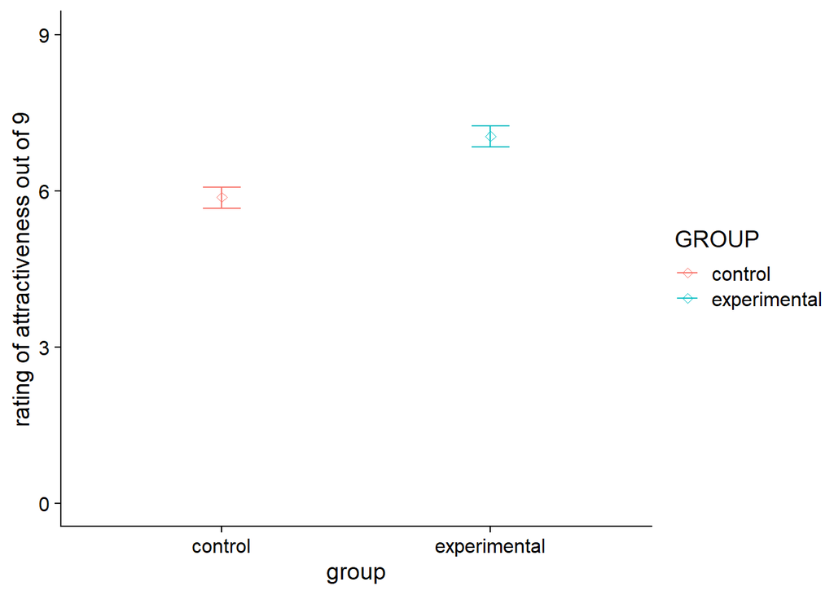

```r
data_means_plot
```

The findings have also been illustrated in graphs for each question, showing that the effect of the colour red on women’s perception of men’s attractiveness was consistent.

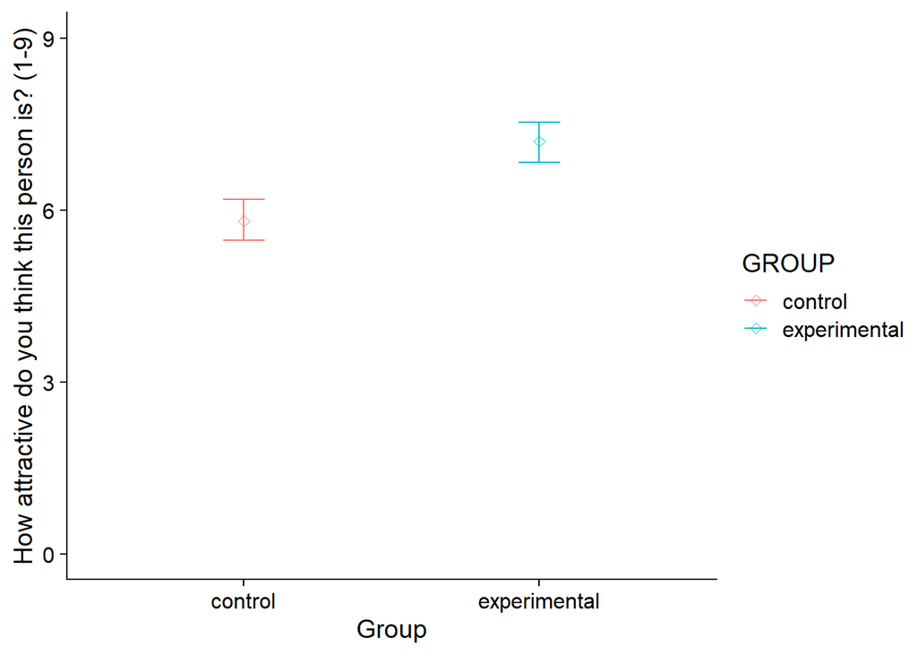

```r
ITEM_1_plot
```

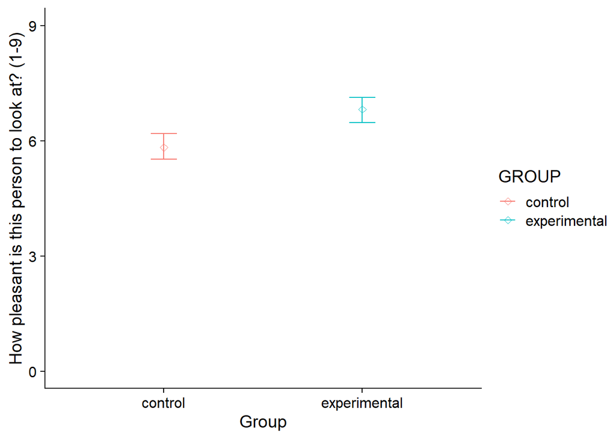

```r
ITEM_2_plot
```

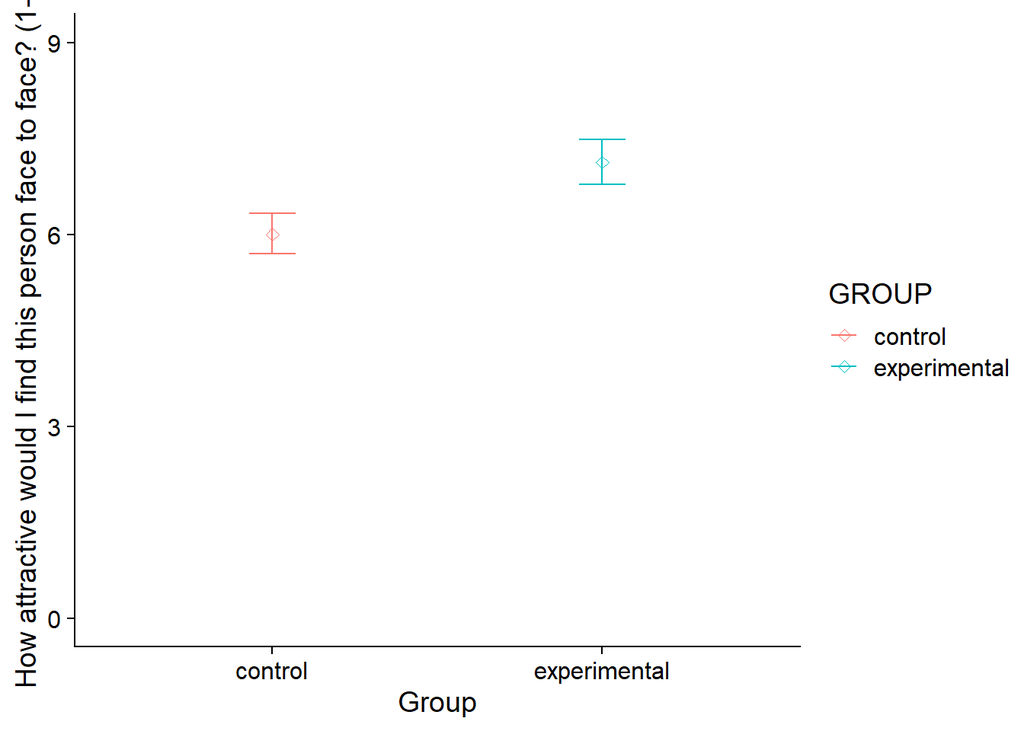

```r
ITEM_3_plot
```

It can be concluded from the data and the resulting t test that the findings of this study indicate that undergraduate women rate men as more attractive when presented in conjunciton with the colour red.

# Discussion

The main findings of this study are that women report significantly higher mean ratings of attractiveness for men when they are presented in conjunction with the colour red.

The present research has been criticised due to the consistency of the findings in other experiments by the same research team being statistically unlikely (Francis., 2013). However, independent research has replicated the findings of the current study (Roberts, Owen & Havlicek., 2010) and the researchers of the current study have replicated their own findings from another experiment investigating the same effect in response to Francis’ (2013) critique (Elliot & Maier., 2013). This provides further evidence that the reported findings of the present research are internally valid.

The present study has also been replicated without producing the same result. Hasselinger, Goldbach and Carbon (2015) found no relationship between the independent and dependent variables when replicating the present research, limiting the validity of the efficacy of the findings from the present study. More research is therefore needed to determine whether there is a relationship between presenting men with the colour red and women’s perceptions of their attractiveness.

In addition, the current research is limited in that the sample is small and not diverse, consisting of all undergraduate women of similar ages. Future research may therefore build upon the present research by replicating the study with more diverse participants in order to explore the observed effect of red on women’s perception of attractiveness in men to produce more representative findings.

A strength of the methodology of the present research is the pilot study conducted to determine which model to use. Using a moderately attractive model means that effects of the independent variable could be measured for negative correlations, positive correlations or no correlations. The researchers for this study have also used independent measures design to blind participants to the aim of the study, which is an appropriate choice for this research as it increases the internal validity of the findings.

The methodology of the present research is limited in that the use of a 9 point ordinal rating scale is limiting and interpretations of each value of the scale may vary depending on individual differences between raters. The study could be improved in future research by using a greater number of scale points, which would yeild findings with greater reliability according to some researchers (Felix., 2011). The present study is also methodologically flawed as it lacks ecological validity, meaning future research should aim to investigate whether the relationship observed is replicated in a setting with more mundane realism, or a natural setting.

The correlation matrix between the questions was conducted to test the internal consistency of the findings as it would be expected that three questions about the attractiveness of the man would result in three very similar answers. A high correlation between answers would indicate that the rating scale is consistent and the data from all questions is a true reflection of the participants’ percieved attractiveness of the male in the study.

```r
ITEM_p_values
```

ITEM correlation *p* ~values

|  | ITEM_1 | ITEM_2 | ITEM_3 |
| --- | --- | --- | --- |
| ITEM_1 | NA | 0.002 | 0.496 |
| ITEM_2 | 0.002 | NA | 0.038 |
| ITEM_3 | 0.496 | 0.038 | NA |

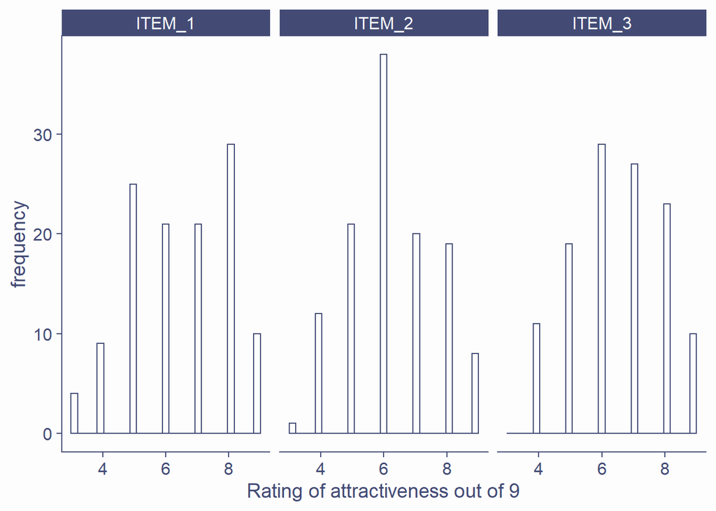

```r
attract_plot
```

Overall, although the findings of the present research are significant, more research is needed in order to produce more reliable, ecologically valid, internally consistent and internally valid findings to assertain whether or not the present research findings are valid. The present research has been reproduced with varying results, suggesting that more research is needed to determine whether there is a relationship between presenting men alongside the colour red and women’s perception of their attractiveness. The present research therefore may serve as a basis for future research to expand on with better desgined studies as the methodology of the current study is not of a high enough standard to accept or reject the findings.

# References

1. Elliot, A. J. & Maier, M. A. (2013). The red-attractiveness effect, applying the Ioannidis and Trikalinos (2007b) test, and the broader scientific context: A reply to Francis (2013). *Journal of Experimental Psychology: General* 142(1), pp. 297-300
2. Felix, R. (2011). The impact of scale width on responses for multi-item self-report measures. *Journal of Targeting, Measurement and Analysis for Marketing*. 19, pp. 153-164
3. Francis, G. (2013) Publication bias in “Red, rank and romance in women viewing men” by Elliot et al (2010). *Journal of Experimental Psychology: General* 142(1), pp. 292-296 Hesslinger, V. M., Goldbach, L. & Carbon, C-C. (2015). Men in red: A re-examination of the red-attractiveness effect. *Psychonomic Bulletin & Review.*. 22, pp. 1142-1148.
4. Roberts, S. C., Owen, R, C. & Havlicek, J. (2010) Distinguishing between perceiver and wearer effects in clothing colour-associated attributions. *Evolutionary Psychology* 8, pp. 350-364.